# Análisis de Dados Multivariados no R

Pacotes que serão necessários

```r
library(leaps)
library(car)
library(MASS)
library(tidyverse)
library(ggplot2)
require(ggcorrplot)
library(factoextra)
library(FactoMineR)
library(psych)
library(dplyr)
```

limpar todas as variáveis do local de trabalho:

```r
rm(list=ls())
```

Leitura de dados

- lendo o dado e transformando em dataframe:

```r
CC <- as.data.frame(read.csv(paste("Hematita.csv",sep=""),header = TRUE,dec = ".",sep = ","))
```

Armazenamento dos dados completos em ‘CC’

```r
head(CC)
```

|  | Est | Repl | DistFoz | Camp | Hem | Est1 |
| --- | --- | --- | --- | --- | --- | --- |
| 1 | D14 | 1 | 39.6 | 1 | 1.91 | 1 |
| 2 | D14 | 2 | 39.6 | 1 | 2.56 | 1 |
| 3 | D14 | 3 | 39.6 | 1 | 1.32 | 1 |
| 4 | D15 | 1 | 41.9 | 1 | 1.66 | 2 |
| 5 | D15 | 2 | 41.9 | 1 | 1.79 | 2 |
| 6 | D15 | 3 | 41.9 | 1 | 1.33 | 2 |

Criando o ‘CC.site’ com as médias do ‘CC’ menos o campo Est, que é categórico

```r
CC.site <- aggregate(. ~ Est,data = CC, FUN = mean )
CC.site
```

| Est | Repl | DistFoz | Camp | Hem | Est1 |
| --- | --- | --- | --- | --- | --- |
| D14 | 2 | 39.6 | 1.5 | 2.1050000 | 1 |
| D15 | 2 | 41.9 | 1.5 | 1.6116667 | 2 |
| D16 | 2 | 44.2 | 1.5 | 1.5433333 | 3 |
| D17 | 2 | 48.9 | 1.5 | 1.2250000 | 4 |
| D18 | 2 | 52.2 | 1.5 | 0.8716667 | 5 |
| D19 | 2 | 55.4 | 1.5 | 0.9950000 | 6 |
| D20 | 2 | 57.1 | 1.5 | 0.7866667 | 7 |
| D21 | 2 | 60.7 | 1.0 | 1.1600000 | 8 |

- Mostrar os nomes de uma estrutura de dados (tabela)
- Retirando a coluna Est que é não numérica:

```r
names(CC.site)
```

```
## [1] "Est"     "Repl"    "DistFoz" "Camp"    "Hem"     "Est1"
```

Escolhendo as variáveis que serão análisadas na **Regressão!**

```r
dados <- CC%>%dplyr::select(Repl,DistFoz,Camp,Hem,Est1)
dados
```

| Repl | DistFoz | Camp | Hem | Est1 |
| --- | --- | --- | --- | --- |
| 1 | 39.6 | 1 | 1.91 | 1 |
| 2 | 39.6 | 1 | 2.56 | 1 |
| 3 | 39.6 | 1 | 1.32 | 1 |
| 1 | 41.9 | 1 | 1.66 | 2 |
| 2 | 41.9 | 1 | 1.79 | 2 |
| 3 | 41.9 | 1 | 1.33 | 2 |
| 1 | 44.2 | 1 | 1.81 | 3 |
| 2 | 44.2 | 1 | 1.23 | 3 |
| 3 | 44.2 | 1 | 2.01 | 3 |
| 1 | 48.9 | 1 | 1.38 | 4 |

[output cut: 35 more lines]

- Gráfico de dispersão DistFoz x Hem

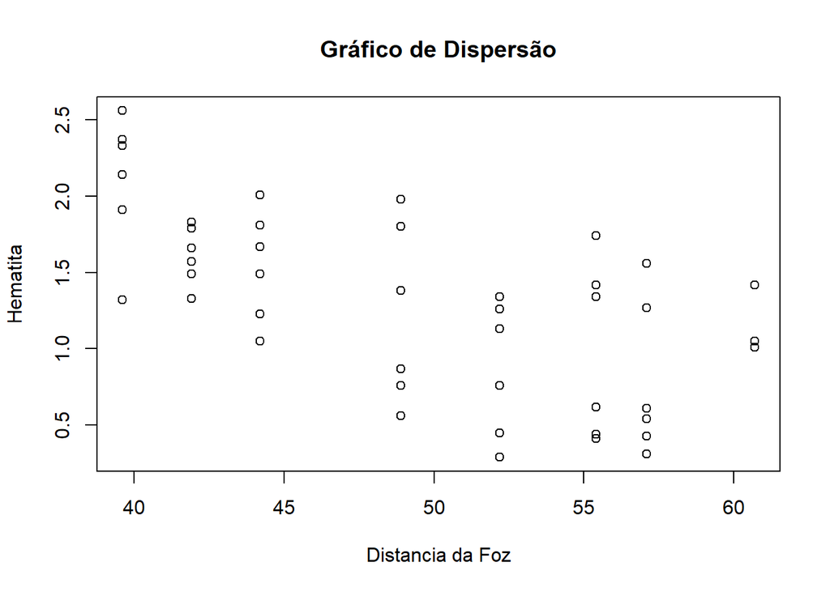

```r
plot(dados$DistFoz,dados$Hem,
     xlab="Distancia da Foz",
     ylab="Hematita",
     main="Gráfico de Dispersão")
```

- Gráfico de dispersão DistFoz x Hem incorporando as variáveis categóricas!

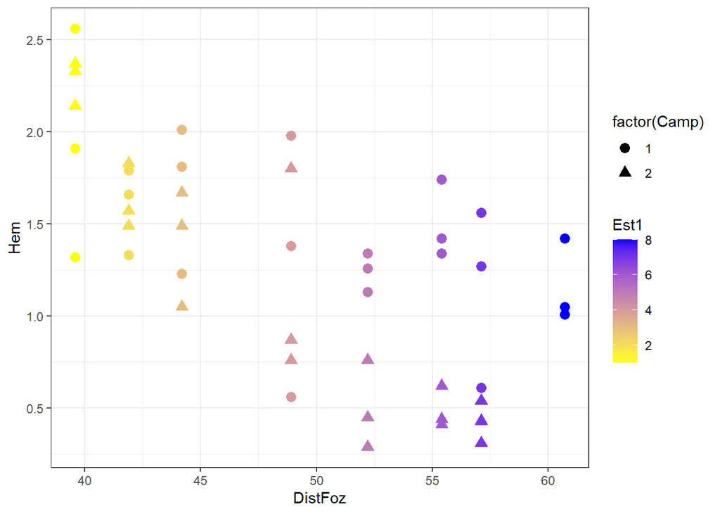

```r
CC %>%
  ggplot(aes(x = DistFoz, y = Hem)) +
  geom_point(aes(shape = factor(Camp), colour=Est1), size = 3) +
  scale_color_continuous(low = "yellow", high = "blue") +
  theme_bw()
```

Amostras coletadas nos *campos*

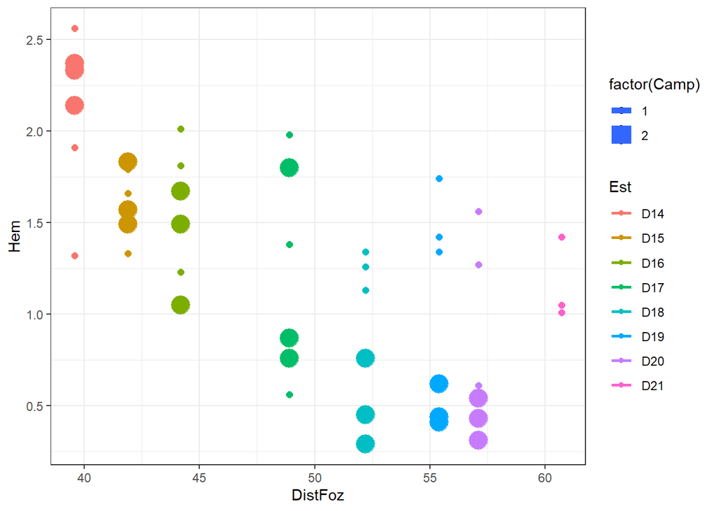

```r
qplot(y=Hem, x=DistFoz, size=factor(Camp), col=Est, data=CC) +
  geom_smooth(method = "lm", se = FALSE) +
  theme_bw()
```

- Boxplot:
- mostra outliers, quartis e a mediana

DistFoz:

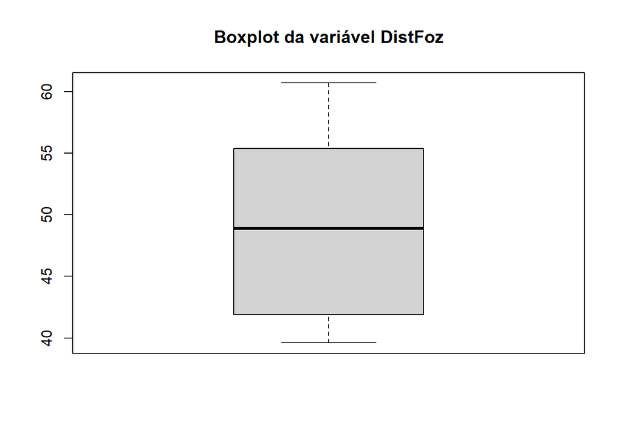

```r
boxplot(dados$DistFoz, main="Boxplot da variável DistFoz")
```

- Dispersão hematita x Est1

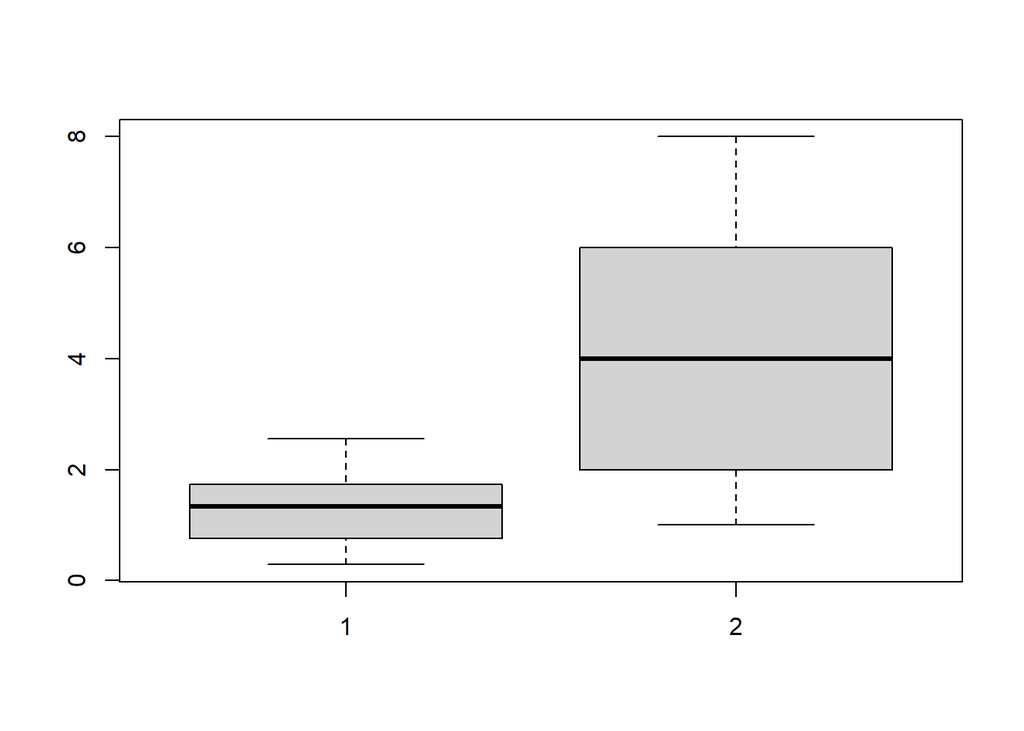

```r
boxplot(dados$Hem,dados$Est1)
```

Explorando todos os dados simultáneamente!

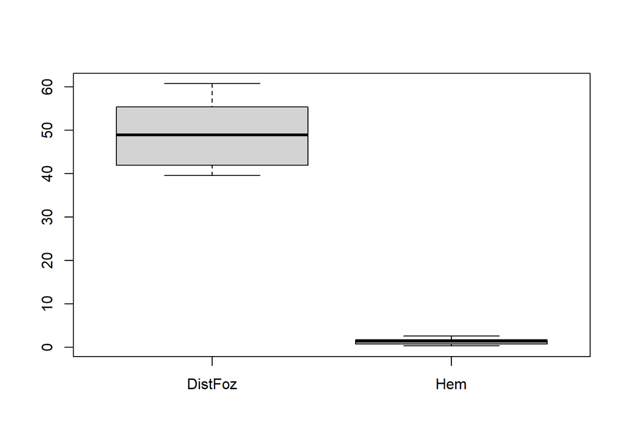

```r
boxplot(dados[c(2,4)])
```

- Transformar?
- Padronizar?

Dados padronizados

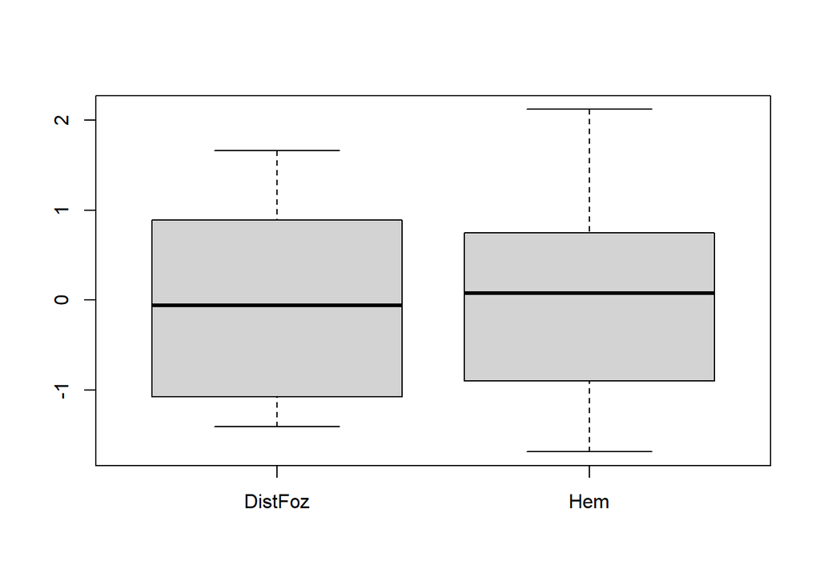

```r
boxplot(scale(dados[c(2,4)]))
```

# 4 Modelo de Regressão

```r
modelo<-lm(Hem~DistFoz+Camp,data=CC)
#modelo<-(Global~Coral+FireCoral+TURF)
```

Sumário: resultados do modelo de regressão linear

```r
summary(modelo)
```

```
##
## Call:
## lm(formula = Hem ~ DistFoz + Camp, data = CC)
##
## Residuals:
##      Min       1Q   Median       3Q      Max
## -0.95019 -0.27674 -0.05586  0.29259  0.72281
##
## Coefficients:
##              Estimate Std. Error t value Pr(>|t|)
## (Intercept)  4.800552   0.515402   9.314 8.95e-12 ***
## DistFoz     -0.058889   0.009264  -6.357 1.22e-07 ***
## Camp        -0.410671   0.126214  -3.254  0.00225 **
## ---
## Signif. codes:  0 '***' 0.001 '**' 0.01 '*' 0.05 '.' 0.1 ' ' 1
##
## Residual standard error: 0.4197 on 42 degrees of freedom
## Multiple R-squared:  0.5278, Adjusted R-squared:  0.5053
## F-statistic: 23.47 on 2 and 42 DF,  p-value: 1.435e-07
```

Teste estatistico para análise de variância:

```r
anova(modelo)
```

|  | Df | Sum Sq | Mean Sq | F value | Pr(>F) |
| --- | --- | --- | --- | --- | --- |
| DistFoz | 1 | 6.404718 | 6.4047185 | 36.35568 | 3.601382e-07 |
| Camp | 1 | 1.865111 | 1.8651108 | 10.58710 | 2.251829e-03 |
| Residuals | 42 | 7.399069 | 0.1761683 | NA | NA |

Análisar os resultados

```r
modelo$coefficients  # coeficientes do modelo (resultados fixos e aleatÓrios)
```

```
## (Intercept)     DistFoz        Camp
##  4.80055231 -0.05888929 -0.41067124
```

```r
modelo$residuals     # residuos do modelo
```

```
##           1           2           3           4           5           6
## -0.14786526  0.50213474 -0.73786526 -0.26241990 -0.13241990 -0.59241990
##           7           8           9          10          11          12
##  0.02302546 -0.55697454  0.22302546 -0.13019488  0.46980512 -0.95019488
##          13          14          15          16          17          18
## -0.05586023 -0.18586023  0.02413977  0.21258549  0.61258549  0.29258549
##          19          20          21          22          23          24
##  0.24269728 -0.41730272  0.53269728  0.23469871  0.60469871  0.19469871
##          25          26          27          28          29          30
##  0.68280598  0.72280598  0.49280598 -0.02174865  0.31825135  0.05825135
##          31          32          33          34          35          36
##  0.29369671  0.11369671 -0.32630329 -0.22952364 -0.33952364  0.70047636
##          37          38          39          40          41          42
## -0.61518899 -0.45518899 -0.14518899 -0.09674327 -0.27674327 -0.30674327
##          43          44          45
## -0.30663148 -0.18663148 -0.07663148
```

```r
modelo$fitted.values # resultado da reta de ajuste do modelo
```

```
##         1         2         3         4         5         6         7         8
## 2.0578653 2.0578653 2.0578653 1.9224199 1.9224199 1.9224199 1.7869745 1.7869745
##         9        10        11        12        13        14        15        16
## 1.7869745 1.5101949 1.5101949 1.5101949 1.3158602 1.3158602 1.3158602 1.1274145
##        17        18        19        20        21        22        23        24
## 1.1274145 1.1274145 1.0273027 1.0273027 1.0273027 0.8153013 0.8153013 0.8153013
##        25        26        27        28        29        30        31        32
## 1.6471940 1.6471940 1.6471940 1.5117487 1.5117487 1.5117487 1.3763033 1.3763033
##        33        34        35        36        37        38        39        40
## 1.3763033 1.0995236 1.0995236 1.0995236 0.9051890 0.9051890 0.9051890 0.7167433
##        41        42        43        44        45
## 0.7167433 0.7167433 0.6166315 0.6166315 0.6166315
```

Explorando e analisando

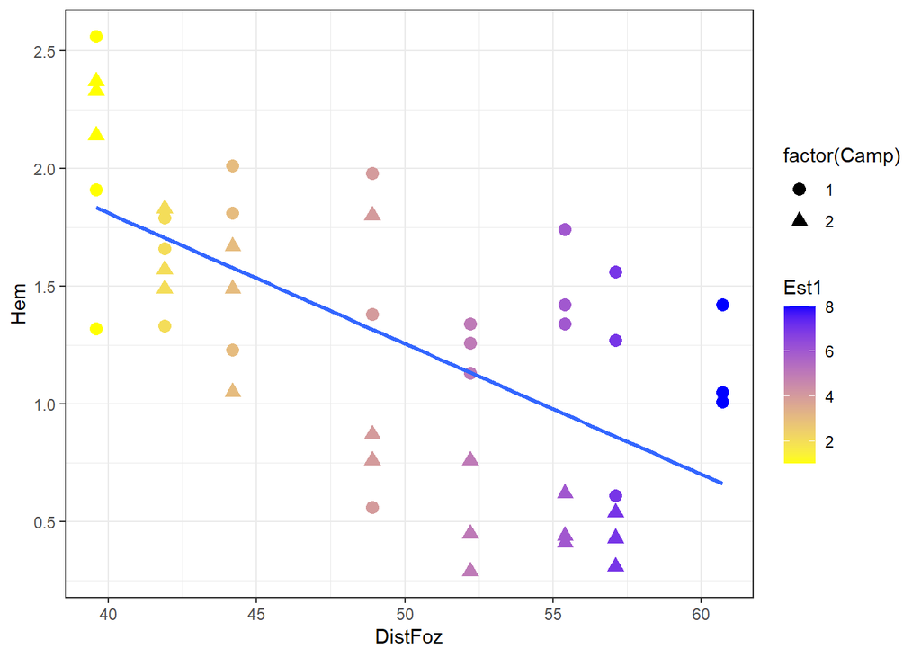

```r
CC %>%
  ggplot(aes(x = DistFoz, y = Hem)) +
  geom_point(aes(shape = factor(Camp), colour=Est1), size = 3) +
  geom_smooth(method = "lm", se = FALSE) +
  scale_color_continuous(low = "yellow", high = "blue") +
  theme_bw()
```

Intervalo de confiança:

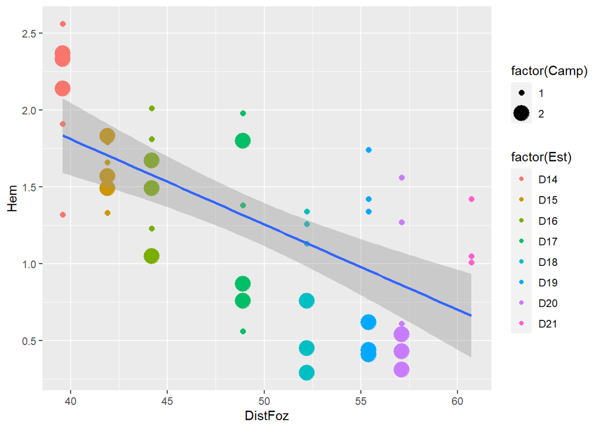

```r
ggplot( CC, aes( y=Hem, x=DistFoz ) ) +
  geom_point( aes(size=factor(Camp), colour=factor(Est)) ) + # geom_point = dispersão
  stat_smooth( method="lm" )
```

Residuos

Verificacao da hipotese de relacao linear entre a resposta e o preditor:

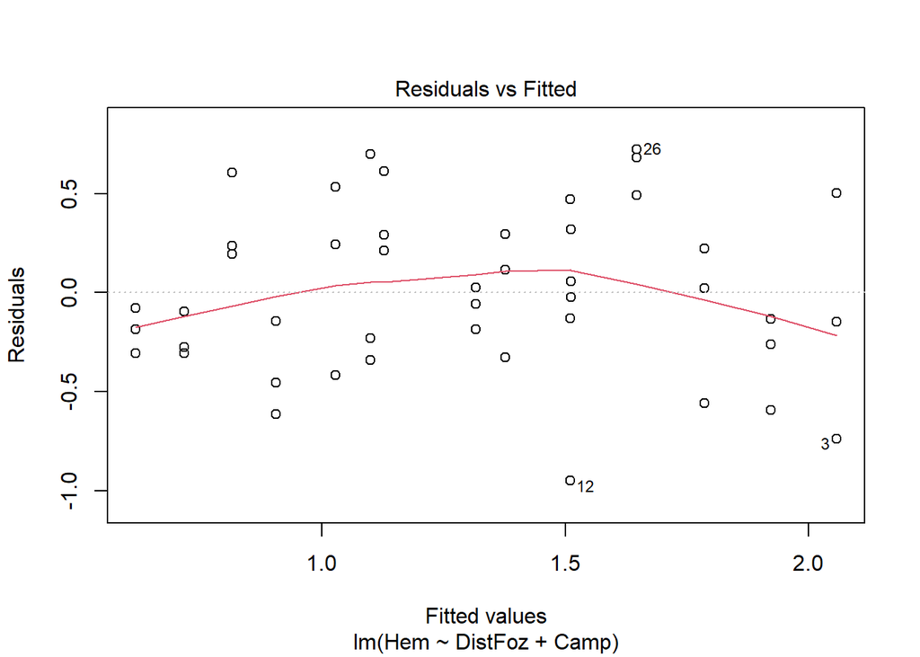

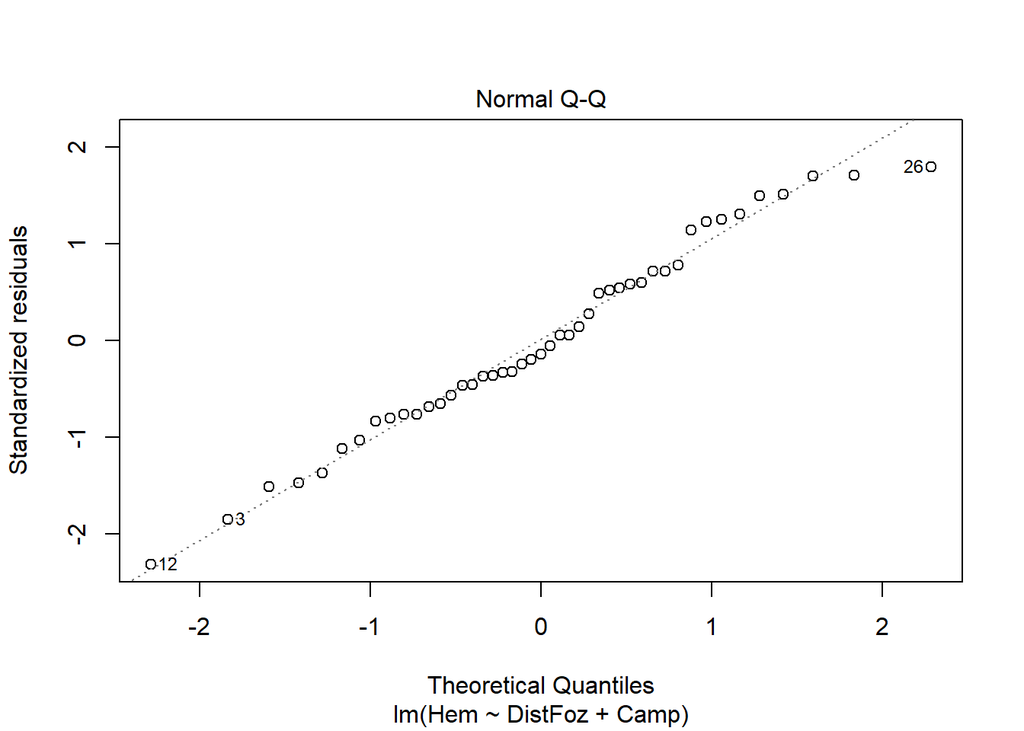

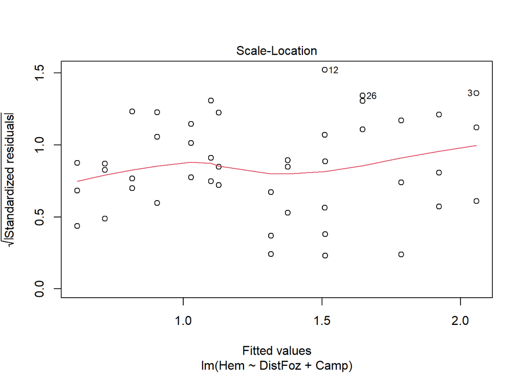

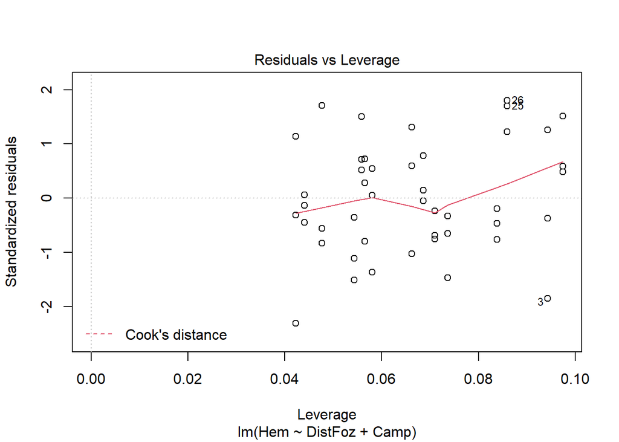

```r
plot(modelo)
```

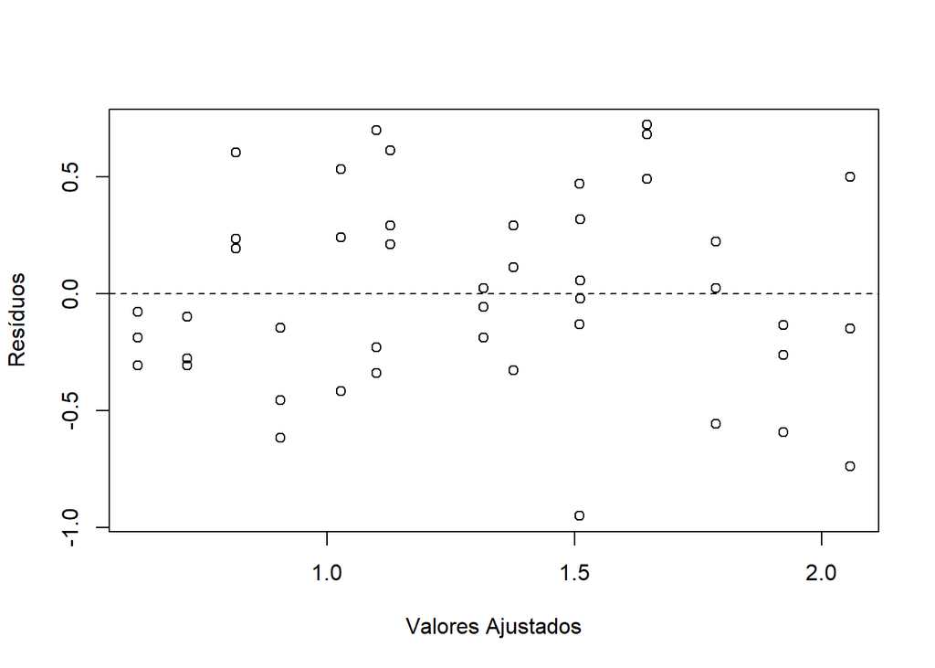

```r
plot(modelo$fitted.values, modelo$residuals,
     xlab="Valores Ajustados", ylab="Resíduos")
abline(h=0,lty=2)
```

Verificando normalidade dos resíduos:

```r
shapiro.test(modelo$residual)
```

```
##
##  Shapiro-Wilk normality test
##
## data:  modelo$residual
## W = 0.97913, p-value = 0.5849
```

qq plot for studentized resid

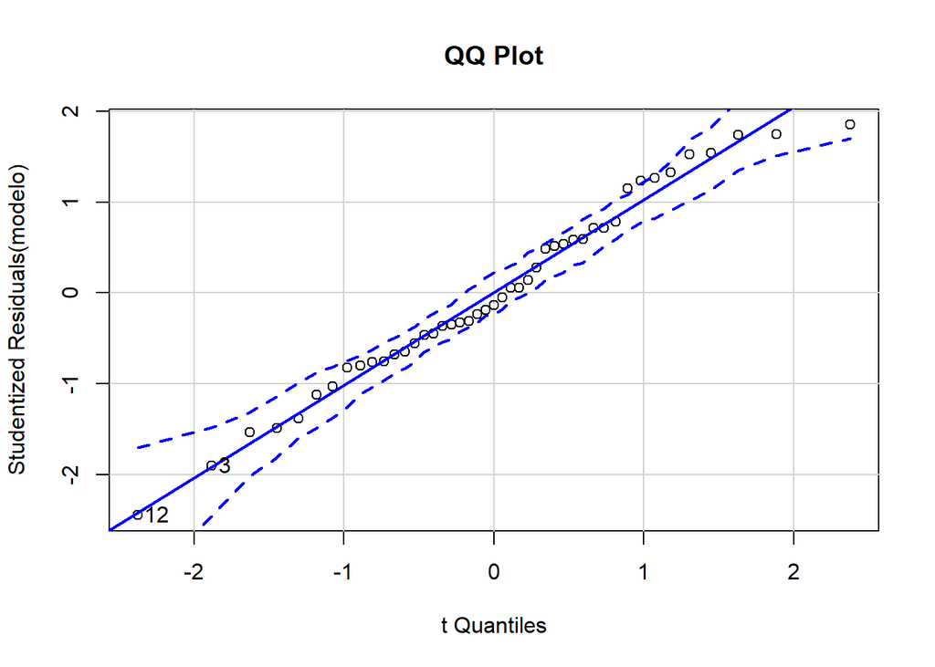

```
## [1]  3 12
```

```r
qqPlot(modelo, main="QQ Plot")
```

Distribution of studentized residuals

```r
sresid <- studres(modelo)
```

Histograma dos Resíduos

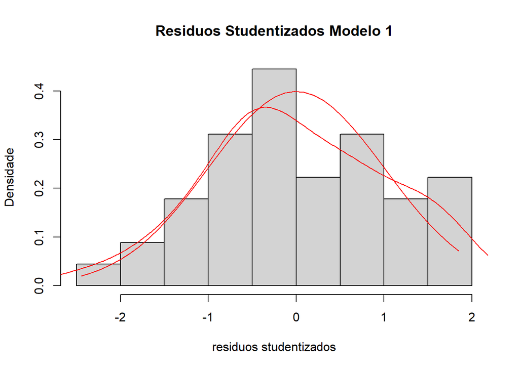

```r
hist(sresid, freq=FALSE,
     ylab="Densidade",xlab="residuos studentizados",
     main="Residuos Studentizados Modelo 1")

xm<-seq(min(sresid),max(sresid),length=40)
ym<-dnorm(xm)

lines(density(sresid),col="red")
lines(xm, ym, col="red")
```

Residuo padronizado:

```r
res_pad=rstandard(modelo)
res_pad
```

```
##           1           2           3           4           5           6
## -0.37019008  1.25712623 -1.84729258 -0.64959241 -0.32779130 -1.46647213
##           7           8           9          10          11          12
##  0.05652387 -1.36728442  0.54749225 -0.31696065  1.14374493 -2.31325828
##          13          14          15          16          17          18
## -0.13611799 -0.45289680  0.05882282  0.52126019  1.50206128  0.71742041
##          19          20          21          22          23          24
##  0.59838421 -1.02888407  1.31339603  0.58858614  1.51648587  0.48827266
##          25          26          27          28          29          30
##  1.70157592  1.80125729  1.22808941 -0.05369253  0.78569089  0.14380945
##          31          32          33          34          35          36
##  0.72038733  0.27887840 -0.80036565 -0.56037479 -0.82893636  1.71019116
##          37          38          39          40          41          42
## -1.50726331 -1.11525023 -0.35572489 -0.23913909 -0.68408000 -0.75823682
##          43          44          45
## -0.76327213 -0.46456615 -0.19075234
```

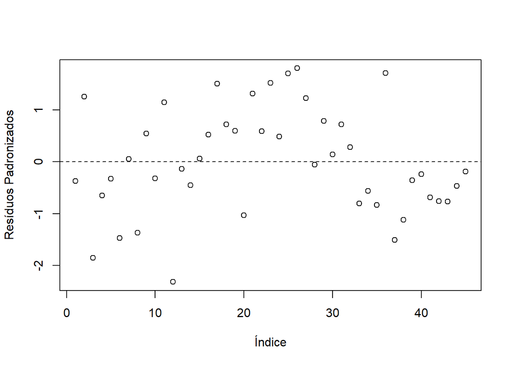

```r
plot(res_pad, xlab="Índice", ylab="Resíduos Padronizados")
abline(h=0,lty=2)
```

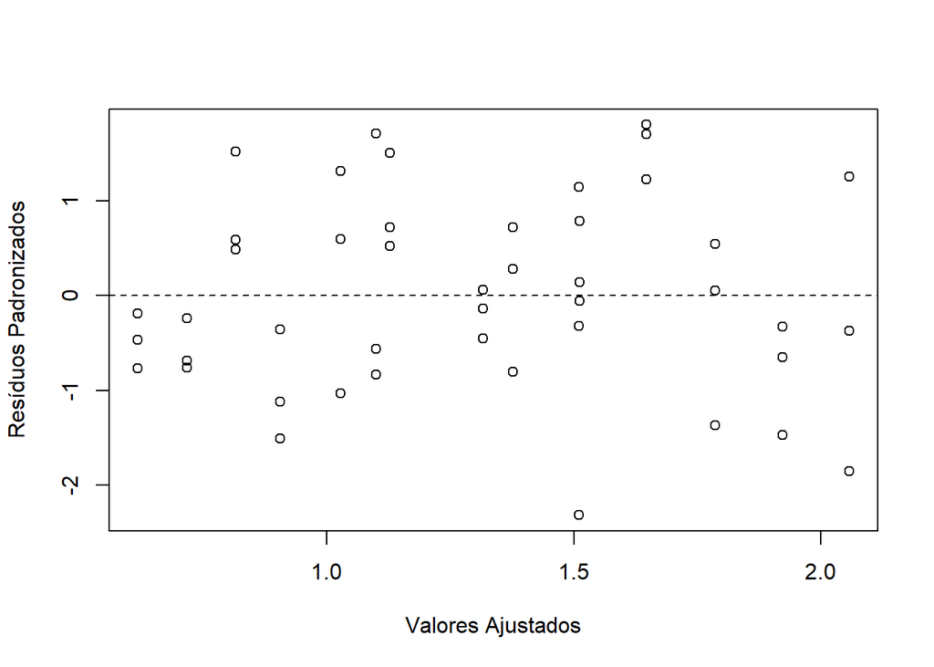

```r
plot(modelo$fitted.values, res_pad,
     xlab="Valores Ajustados", ylab="Resíduos Padronizados")
abline(h=0,lty=2)
```

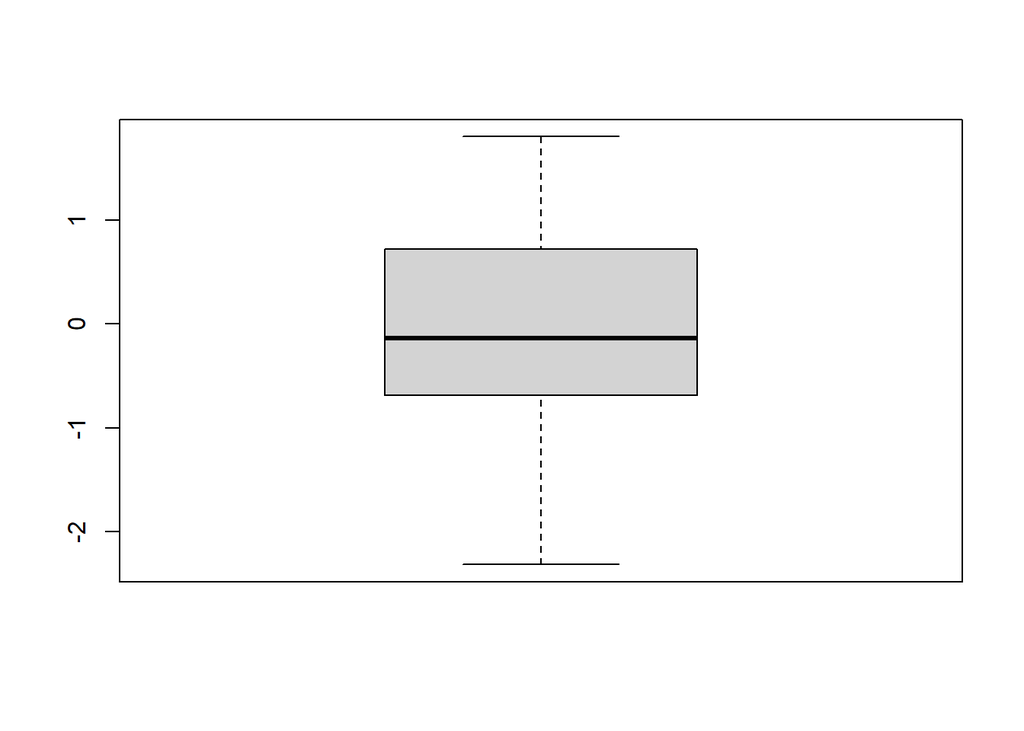

```r
boxplot(res_pad)
```

Residuo Studentizado:

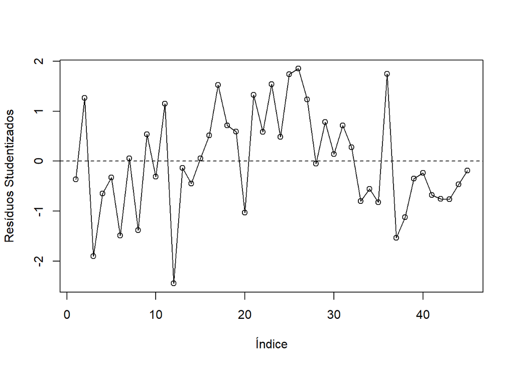

```r
res_stu=rstudent(modelo)
plot(res_stu, xlab="Índice", ylab="Resíduos Studentizados")
abline(h=0,lty=2)
lines(res_stu) #Ausência de padrão, ou seja, erros não correlacionados.
```

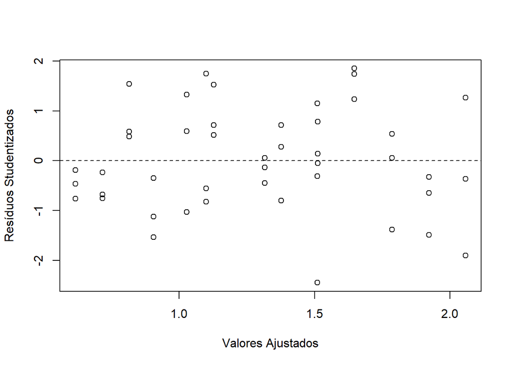

```r
plot(modelo$fitted.values,res_stu,
     xlab="Valores Ajustados", ylab="Resíduos Studentizados")
abline(h=0,lty=2)
```